# DATA 607 Final Project

Susanna Wong

2023-04-30

# Data

Crime Data: Use publicly available crime data from the New York City Open Data. The data includes information such as the type of crime, the location of the crime, the date of the crime, information of perpetrators.

NY Borough Population Size: Webscrap population size of each NY borough from CityPopulation. The website contains the population of each NY borough according to census results. https://www.citypopulation.de/en/usa/newyorkcity/

## NYC Open Data

| Column Name | Description | Data Type |
| --- | --- | --- |
| ARREST_KEY | Randomly generated persistent ID for each arrest | int |
| ARREST_DATE | Exact date of arrest for the reported event | chr |
| PD_CD | Three digit internal classification code (more granular than Key Code) | int |
| PD_DESC | Description of internal classification corresponding with PD code (more granular than Offense Description) | chr |
| KY_CD | Three digit internal classification code (more general category than PD code) | int |
| OFNS_DESC | Description of internal classification corresponding with KY code (more general category than PD description) | chr |
| LAW_CODE | Law code charges corresponding to the NYS Penal Law, VTL and other various local laws | chr |
| LAW_CAT_CD | Level of offense: felony, misdemeanor, violation | chr |
| ARREST_BORO | Borough of arrest. B(Bronx), S(Staten Island), K(Brooklyn), M(Manhattan), Q(Queens) | chr |
| ARREST_PRECINCT | Precinct where the arrest occurred | int |
| JURISDICTION_CODE | Jurisdiction responsible for arrest. Jurisdiction codes 0(Patrol), 1(Transit) and 2(Housing) represent NYPD whilst codes 3 and more represent non NYPD jurisdictions | int |
| AGE_GROUP | Perpetrator’s age within a category | chr |
| PERP_SEX | Perpetrator’s sex description | chr |
| PERP_RACE | Perpetrator’s race description | chr |
| X_COORD_CD | Midblock X-coordinate for New York State Plane Coordinate System, Long Island Zone, NAD 83, units feet (FIPS 3104) | int |
| Y_COORD_CD | Midblock Y-coordinate for New York State Plane Coordinate System, Long Island Zone, NAD 83, units feet (FIPS 3104) | int |
| Latitude | Latitude coordinate for Global Coordinate System, WGS 1984, decimal degrees (EPSG 4326) | num |
| Longitude | Longitude coordinate for Global Coordinate System, WGS 1984, decimal degrees (EPSG 4326) | num |
| Lon_Lat | Georeferenced Point Column based on Longitude and Latitude fields | chr |
| Zip.Codes | Zip code of arrest | int |
| Community.Districts |  | int |
| Borough.Boundaries |  | int |
| City.Council.Districts |  | int |
| Police.Precincts |  | int |

```r
data_2022 <- read.csv("https://raw.githubusercontent.com/suswong/DATA-607-Final-Project/main/NYPD_Arrests_Data__Historic_-2022.csv", header = T, na.strings = "NA")

data_2021 <- read.csv("https://raw.githubusercontent.com/suswong/DATA-607-Final-Project/main/NYPD_Arrests_Data__Historic_-2021.csv", header = T, na.strings = "NA")

data_2020 <- read.csv("https://raw.githubusercontent.com/suswong/DATA-607-Final-Project/main/NYPD_Arrests_Data__Historic_-2020.csv", header = T, na.strings = "NA")

data_2019 <- read.csv("https://raw.githubusercontent.com/suswong/DATA-607-Final-Project/main/NYPD_Arrests_Data__Historic_-2019.csv", header = T, na.strings = "NA")

data_2018 <- read.csv("https://raw.githubusercontent.com/suswong/DATA-607-Final-Project/main/NYPD_Arrests_Data__Historic_2018.csv", header = T, na.strings = "NA")

data_2018_2022 <- rbind(data_2018,data_2019,data_2020,data_2021,data_2022)
```

## NY Population

```r
library(rvest)
web = read_html("https://www.citypopulation.de/en/usa/newyorkcity/")
HTML_df <- html_table(web)
population <- HTML_df[[1]]

library(DT)
datatable(population)
```

|  | Name | Status | PopulationCensus1990-04-01 | PopulationCensus2000-04-01 | PopulationCensus2010-04-01 | PopulationCensus2020-04-01 | PopulationEstimate2022-07-01 | Var.9 |
| --- | --- | --- | --- | --- | --- | --- | --- | --- |
| 1 | Bronx | Borough | 1,203,789 | 1,332,650 | 1,385,108 | 1,472,654 | 1,379,946 | → |
| 2 | Brooklyn (Kings County) | Borough | 2,300,664 | 2,465,326 | 2,504,700 | 2,736,074 | 2,590,516 | → |
| 3 | Manhattan (New York County) | Borough | 1,487,536 | 1,537,195 | 1,585,873 | 1,694,251 | 1,596,273 | → |
| 4 | Queens | Borough | 1,951,598 | 2,229,379 | 2,230,722 | 2,405,464 | 2,278,029 | → |
| 5 | Staten Island (Richmond County) | Borough | 378,977 | 443,728 | 468,730 | 495,747 | 491,133 | → |
| 6 | New York City | City | 7,322,564 | 8,008,278 | 8,175,133 | 8,804,190 | 8,335,897 |  |

# Tidying Data

## NYC Arrest Data

Below are some of things that needs to be tidied for the analysis:

- Remove columns that are not needed in the analysis
- Rename values in the ‘ARREST_BORO’ column
- Change format of ‘ARREST_DATE’ to date format
- Missing values

### Remove columns

Use `str()` to check the structure of each dataset.

We do not need the following columns in our analysis:

- ARREST_KEY
- PD_CD
- KY_CD
- LAW_CODE
- ARREST_PRECINCT
- JURISDICTION_CODE
- Community.Districts
- Borough.Boundaries
- City.Council.Districts
- Police.Precincts

```r
str(data_2018_2022)
```

```
## 'data.frame':    946631 obs. of  24 variables:
##  $ ARREST_KEY            : int  173151631 173188566 173175365 173169664 173163856 173172244 173163850 173186220 173151563 173191179 ...
##  $ ARREST_DATE           : chr  "01/02/2018" "01/02/2018" "01/02/2018" "01/02/2018" ...
##  $ PD_CD                 : int  205 101 101 139 339 339 101 922 567 113 ...
##  $ PD_DESC               : chr  "TRESPASS 2, CRIMINAL" "ASSAULT 3" "ASSAULT 3" "MURDER,UNCLASSIFIED" ...
##  $ KY_CD                 : int  352 344 344 101 341 341 344 348 235 344 ...
##  $ OFNS_DESC             : chr  "CRIMINAL TRESPASS" "ASSAULT 3 & RELATED OFFENSES" "ASSAULT 3 & RELATED OFFENSES" "MURDER & NON-NEGL. MANSLAUGHTER" ...
##  $ LAW_CODE              : chr  "PL 1401500" "PL 1200001" "PL 1200001" "PL 1252501" ...
##  $ LAW_CAT_CD            : chr  "M" "M" "M" "F" ...
##  $ ARREST_BORO           : chr  "M" "K" "M" "B" ...
##  $ ARREST_PRECINCT       : int  28 67 14 42 14 62 94 34 23 14 ...
##  $ JURISDICTION_CODE     : int  2 0 0 0 6 0 0 0 2 0 ...
##  $ AGE_GROUP             : chr  "45-64" "25-44" "25-44" "25-44" ...
##  $ PERP_SEX              : chr  "M" "M" "M" "M" ...
##  $ PERP_RACE             : chr  "BLACK" "BLACK" "BLACK" "BLACK HISPANIC" ...
##  $ X_COORD_CD            : int  997875 997897 988191 1008691 986781 987061 997245 1002024 1000866 985802 ...
##  $ Y_COORD_CD            : int  230878 175677 215312 238872 212761 164953 204130 249023 226632 213781 ...
##  $ Latitude              : num  40.8 40.6 40.8 40.8 40.8 ...
##  $ Longitude             : num  -74 -74 -74 -73.9 -74 ...
##  $ Lon_Lat               : chr  "POINT (-73.95078943299995 40.80038048100005)" "POINT (-73.95082189999994 40.64886713300007)" "POINT (-73.98577611499996 40.75766554000006)" "POINT (-73.91169413099993 40.82229848500003)" ...
##  $ Zip.Codes             : int  12423 13510 13094 10929 11722 16867 18182 13091 12426 12080 ...
##  $ Community.Districts   : int  18 61 11 34 11 1 36 47 7 12 ...
##  $ Borough.Boundaries    : int  4 2 4 5 4 2 2 4 4 4 ...
##  $ City.Council.Districts: int  36 11 10 43 10 7 38 39 35 10 ...
##  $ Police.Precincts      : int  18 40 8 25 8 37 57 22 14 8 ...
```

```r
library(dplyr)
data_2018_2022 <- data_2018_2022 %>%
  select(-ARREST_KEY,-KY_CD, -PD_CD, -LAW_CODE, -ARREST_PRECINCT, -JURISDICTION_CODE, -Community.Districts, -Borough.Boundaries, -City.Council.Districts, -Police.Precincts)
```

### Rename Values in ‘ARREST_BORO’

The ‘ARREST_BORO’ column contains the borough in which the arrest was made. However, those values are in abbreviation.

```r
data_2018_2022$ARREST_BORO[grep("B", data_2018_2022$ARREST_BORO)] <- "Bronx"
data_2018_2022$ARREST_BORO[grep("K", data_2018_2022$ARREST_BORO)] <- "Brooklyn"
data_2018_2022$ARREST_BORO[grep("M", data_2018_2022$ARREST_BORO)] <- "Manhattan"
data_2018_2022$ARREST_BORO[grep("Q", data_2018_2022$ARREST_BORO)] <- "Queens"
data_2018_2022$ARREST_BORO[grep("S", data_2018_2022$ARREST_BORO)] <- "Staten Island"
```

### Change format of ‘ARREST_DATE’

The ‘ARREST_DATE’ needs to be converted to date format.

```r
data_2018_2022$ARREST_DATE <- as.Date(data_2018_2022$ARREST_DATE, format = "%m/%d/%Y" )

data_2018_2022$YEAR <- as.numeric(format(data_2018_2022$ARREST_DATE,'%Y'))
```

### Missing Values

Use `colSums(is.na())` to check for missing values. There are 2093 missing values in the ‘Zip.Codes’ column.

```r
colSums(is.na(data_2018_2022))
```

```
## ARREST_DATE     PD_DESC   OFNS_DESC  LAW_CAT_CD ARREST_BORO   AGE_GROUP
##           0           0           0           0           0           0
##    PERP_SEX   PERP_RACE  X_COORD_CD  Y_COORD_CD    Latitude   Longitude
##           0           0           0           0           0           0
##     Lon_Lat   Zip.Codes        YEAR
##           0        2093           0
```

```r
data_2018_2022 <- data_2018_2022[complete.cases(data_2018_2022),]

colSums(is.na(data_2018_2022))
```

```
## ARREST_DATE     PD_DESC   OFNS_DESC  LAW_CAT_CD ARREST_BORO   AGE_GROUP
##           0           0           0           0           0           0
##    PERP_SEX   PERP_RACE  X_COORD_CD  Y_COORD_CD    Latitude   Longitude
##           0           0           0           0           0           0
##     Lon_Lat   Zip.Codes        YEAR
##           0           0           0
```

### Duplicates

Check for duplicates

```r
distinct(data_2018_2022)
```

[output not shown]

[output cut: 33321 more lines]

## NY Population by Borough

To calculate the crime rate by borough, we need the population of each borough. We will only need the population census in 2020.

Below are some of things that needs to be tidied for the analysis:

- Remove columns that are not needed in the analysis
- Rename column labels
- Change format of the population column to numeric

### Remove columns

```r
population_boro <- population[, -c(2:5,7:8)] #Removes the other years' population size except for 2020

population_boro <- as.data.frame(population_boro)
datatable(population_boro)
```

|  | Name | PopulationCensus2020-04-01 |
| --- | --- | --- |
| 1 | Bronx | 1,472,654 |
| 2 | Brooklyn (Kings County) | 2,736,074 |
| 3 | Manhattan (New York County) | 1,694,251 |
| 4 | Queens | 2,405,464 |
| 5 | Staten Island (Richmond County) | 495,747 |
| 6 | New York City | 8,804,190 |

### Rename Column and Values

```r
colnames(population_boro) <- c("Borough", "Population_Census_2020")
population_boro$Borough[grep("Bronx", population_boro$Borough)] <- "Bronx"
population_boro$Borough[grep("Brooklyn", population_boro$Borough)] <- "Brooklyn"
population_boro$Borough[grep("Staten Island", population_boro$Borough)] <- "Staten Island"
population_boro$Borough[grep("Manhattan", population_boro$Borough)] <- "Manhattan"

str(population_boro)
```

```
## 'data.frame':    6 obs. of  2 variables:
##  $ Borough               : chr  "Bronx" "Brooklyn" "Manhattan" "Queens" ...
##  $ Population_Census_2020: chr  "1,472,654" "2,736,074" "1,694,251" "2,405,464" ...
```

```r
population_boro$Population_Census_2020 <- as.numeric(gsub(",","",population_boro$Population_Census_2020))
```

# Analysis

## Top 10 Offenses in NY

### Datatable

```r
library(ggplot2)

offense <- data_2018_2022 %>%
  group_by(OFNS_DESC) %>%
  summarise(count = n())

datatable(offense)
```

|  | OFNS_DESC | count |
| --- | --- | --- |
| 1 |  | 1222 |
| 2 | (null) | 570 |
| 3 | ABORTION | 3 |
| 4 | ADMINISTRATIVE CODE | 2042 |
| 5 | ADMINISTRATIVE CODES | 24 |
| 6 | AGRICULTURE &amp; MRKTS LAW-UNCLASSIFIED | 262 |
| 7 | ALCOHOLIC BEVERAGE CONTROL LAW | 1656 |
| 8 | ANTICIPATORY OFFENSES | 206 |
| 9 | ARSON | 600 |
| 10 | ASSAULT 3 &amp; RELATED OFFENSES | 147209 |

[output cut: 76 more lines]

### Visualization

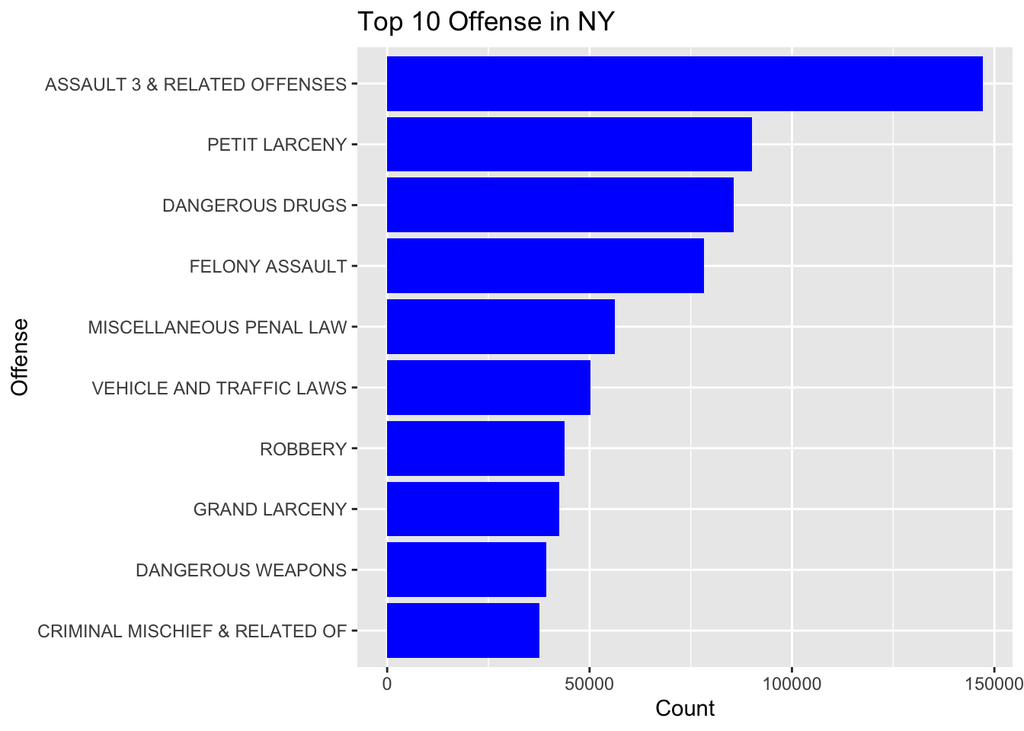

```r
offense %>%
    arrange(desc(count)) %>%
    slice(1:10) %>%
    ggplot(., aes(x=reorder(OFNS_DESC, count), y=count))+
              geom_bar(stat='identity', fill="blue") + coord_flip() + xlab("Offense")+ ylab("Count") +
  ggtitle("Top 10 Offense in NY")
```

## Crime Rate by Borough and Year

Calculate the crime rate for each borough by dividing the number of arrests in each borough by its population. This will allow us to compare crime rates on an equal basis across different boroughs.

### Datatable

```r
# Count the number of arrests in each borough by year
borough_by_year <- data_2018_2022 %>%
  group_by(YEAR, ARREST_BORO) %>%
  summarise(count = n())
# Create a new column for the population size for each borough
borough_by_year$population <-
  with(borough_by_year, ifelse(ARREST_BORO == "Brooklyn", population_boro[2,2],
                         ifelse(ARREST_BORO == "Bronx", population_boro[1,2],
                        ifelse(ARREST_BORO == "Queens", population_boro[4,2],
                         ifelse(ARREST_BORO == "Manhattan", population_boro[3,2],population_boro[5,2]      )))))

# Rename column names
colnames(borough_by_year) <- c("Year" ,"Borough", "count", "population")

# Calculate the crime rate per year and borough
borough_by_year <- borough_by_year %>%
  mutate(crime_rate = (count/population)*1000)

datatable(borough_by_year)
```

|  | Year | Borough | count | population | crime_rate |
| --- | --- | --- | --- | --- | --- |
| 1 | 2018 | Bronx | 55208 | 1472654 | 37.4887787626965 |
| 2 | 2018 | Brooklyn | 68150 | 2736074 | 24.9079520510045 |
| 3 | 2018 | Manhattan | 62146 | 1694251 | 36.6805154608142 |
| 4 | 2018 | Queens | 49777 | 2405464 | 20.6933049091568 |
| 5 | 2018 | Staten Island | 10391 | 495747 | 20.9602882115273 |
| 6 | 2019 | Bronx | 48707 | 1472654 | 33.0742998694873 |
| 7 | 2019 | Brooklyn | 58213 | 2736074 | 21.2761058363188 |
| 8 | 2019 | Manhattan | 53610 | 1694251 | 31.6423009341591 |
| 9 | 2019 | Queens | 44538 | 2405464 | 18.5153467272842 |
| 10 | 2019 | Staten Island | 9021 | 495747 | 18.1967818262138 |

[output cut: 15 more lines]

### Visualization

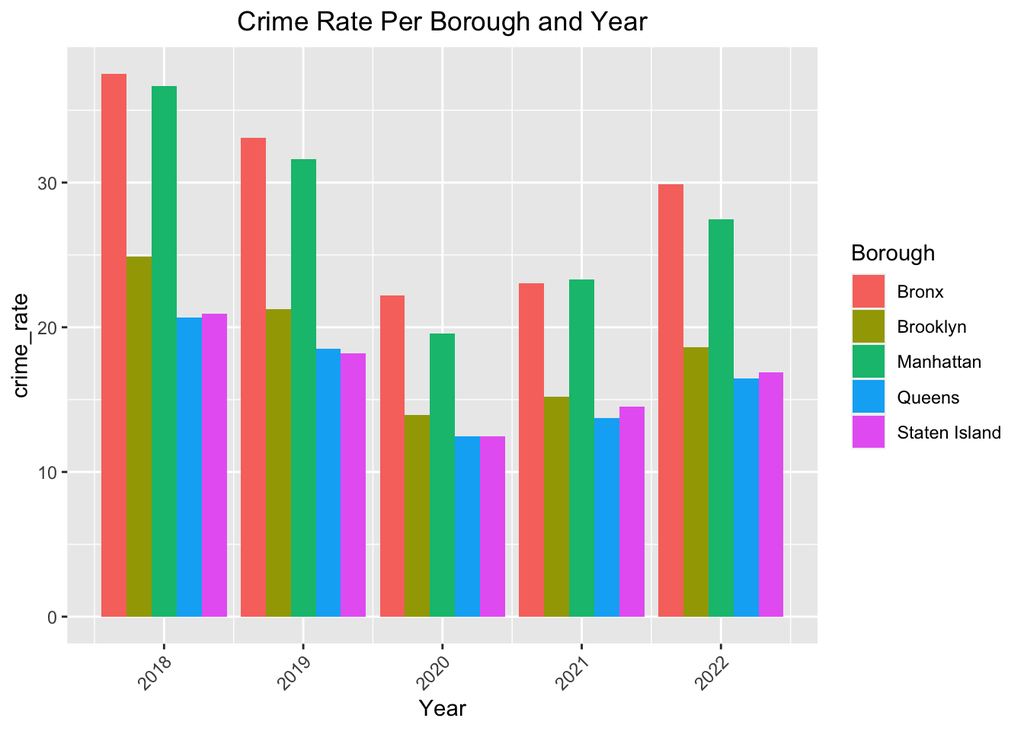

```r
ggplot(borough_by_year, aes(fill=Borough, y= crime_rate, x=Year)) +
  ggtitle("Crime Rate Per Borough and Year") + theme(plot.title=element_text(hjust=0.5))+
  theme(axis.text.x=element_text(angle=45,hjust=1)) +
    geom_bar(position="dodge", stat="identity")
```

```r
# + scale_y_continuous(labels = scales::percent)
```

```r
crime_by_borough <- data_2018_2022 %>%
  group_by(OFNS_DESC,ARREST_BORO) %>%
  summarise(count = n())
crime_by_borough$population <-
  with(crime_by_borough, ifelse(ARREST_BORO == "Brooklyn", population_boro[2,2],
                         ifelse(ARREST_BORO == "Bronx", population_boro[1,2],
                        ifelse(ARREST_BORO == "Queens", population_boro[4,2],
                         ifelse(ARREST_BORO == "Manhattan", population_boro[3,2],population_boro[5,2]      )))))

crime_by_borough <- crime_by_borough %>%
  group_by(ARREST_BORO) %>%
  mutate(offense_rate = (count/sum(count)))

# crime_by_borough <- crime_by_borough %>%
#   filter(crime_rate > 5000)
```

### Top Offense Per Borough

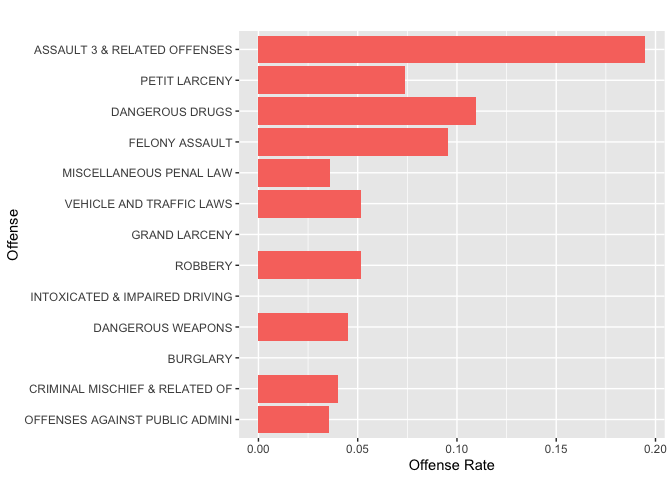

```r
#install.packages("gganimate")
#install.packages("gifski")

library(gganimate)
library(gifski)


p <- crime_by_borough %>%
  arrange(desc(offense_rate)) %>%
  group_by(ARREST_BORO) %>%
  slice(1:10) %>%
    ggplot(., aes(x = reorder(OFNS_DESC, offense_rate),
                                                 y = offense_rate,
                                                 fill = ARREST_BORO)) +
    geom_bar(stat = "identity", show.legend = FALSE) +
    labs(title = "") +
    coord_flip()  +
    xlab("Offense") +
    ylab("Offense Rate")

a <- p +
    transition_states(ARREST_BORO, wrap = FALSE)
animate(a, nframes = 5, fps = 1)
```